Navigation

In Vitro Report

# In Vitro Fit Report

/share/lab_crd/lab_crd/taoli/Project/miningcloneid_soft_coupling/oxygen/results/fit_invitro_O2G_buffering_500seed/seed350

Generated: 2026-05-29 16:02:35 EDT

## Fit Summary

| metric | value |
| --- | --- |
| fit_mode | fit_invitro |
| objective_total | 3.811 |
| total_loglik | -3.811 |
| growth_loglik | 0.202 |
| ploidy_loglik | -3.102 |
| flow_loglik | -0.912 |
| growth_loglik_sum | 23.020 |
| ploidy_loglik_sum | -37.220 |
| flow_loglik_sum | -18.233 |
| n_growth | 114 |
| n_growth_observed | 114 |
| n_ploidy_passages | 12 |
| n_kary_cells | 220 |
| n_flow_passages | 20 |
| n_flow_samples | 20 |
| seed | 350 |
| itermax | 500 |
| itermax_requested | 500 |
| itermax_max | 500 |
| de_reltol | 1.000e-04 |
| de_steptol | 25 |
| NP_requested | 80 |
| NP_used | 200 |
| n_cores_requested | 22 |
| n_cores_used | 22 |
| parameter_table | /share/lab_crd/lab_crd/taoli/Project/miningcloneid_soft_coupling/oxygen/data/O2G_supply_demand/parameter_table_invitro_buffering.csv |
| fit_objects_dir | /share/lab_crd/lab_crd/taoli/Project/miningcloneid_soft_coupling/oxygen/ploidyOxygen/data/fit_objects |
| flow_density_path | /share/lab_crd/lab_crd/taoli/Project/miningcloneid_soft_coupling/oxygen/data/g0g1_ploidy_density_grid.csv |

## Best Parameters

### Fitted Parameters

| parameter | parameter_description | value |
| --- | --- | --- |
| lam_max | maximum division rate lam_max in day^-1 | 1.388 |
| p_misseg | stress-linked missegregation amplification scale | 0.010 |
| k_o_mis | half-saturation scale for death-linked missegregation amplification in day^-1 | 1.000e-05 |
| p_wgd | whole-genome doubling probability | 0.001 |
| alpha_o2 | soft oxygen-mediated high-ploidy growth penalty strength | 0.500 |
| gamma_growth | exponent for the soft oxygen-mediated ploidy growth penalty | 1.500 |
| mu_hp | soft thresholded high-ploidy hypoxia death strength in day^-1 | 0.001 |
| gamma_mu | exponent for high-ploidy hypoxia death above diploid reference | 2.174 |
| O2_crit | Hill critical oxygen scale for the oxygen-response weight | 1.979 |
| n_O | Hill exponent for the oxygen-response weight | 2.173 |
| sigma_growth | shared standard deviation of growth-rate observations in the in vitro likelihood | 0.197 |
| sigma_kary | shared standard deviation of chromosome-count observation error used to smooth the model-predicted N distribution before evaluating the in vitro likelihood | 0.079 |
| init_mean_2N | initial 2N-cohort Gaussian chromosome-count mean from early normoxic karyotypes | 46.643 |
| init_sd_2N | initial 2N-cohort Gaussian chromosome-count SD from early normoxic karyotypes | 2.415 |
| init_mean_4N | initial 4N-cohort Gaussian chromosome-count mean from early normoxic karyotypes | 84.036 |
| init_sd_4N | initial 4N-cohort Gaussian chromosome-count SD from early normoxic karyotypes | 1.579 |
| p_mis_base | fixed baseline per-chromosome missegregation probability | 3.236e-04 |

### Fixed Parameters Used By Current Mode

| parameter | parameter_description | value |
| --- | --- | --- |
| buffer_smax | maximum per-copy survival factor for symmetric buffering missegregation survival | 1 |
| buffer_beta | ploidy-buffering strength for symmetric missegregation survival | 1.508 |
| buffer_n_exp | ploidy-buffering exponent for symmetric missegregation survival | 3.058 |

## Transformed Parameters

### Fitted Parameters

| transformed_parameter | parameter_description | transformed_value |
| --- | --- | --- |
| log10_lam_max | maximum division rate lam_max in day^-1 | 0.143 |
| log10_p_misseg | stress-linked missegregation amplification scale | -1.986 |
| log10_k_o_mis | half-saturation scale for death-linked missegregation amplification in day^-1 | -5 |
| log10_p_wgd | whole-genome doubling probability | -3.226 |
| log10_alpha_o2 | soft oxygen-mediated high-ploidy growth penalty strength | -0.301 |
| gamma_growth | exponent for the soft oxygen-mediated ploidy growth penalty | 1.500 |
| log10_mu_hp | soft thresholded high-ploidy hypoxia death strength in day^-1 | -3.229 |
| gamma_mu | exponent for high-ploidy hypoxia death above diploid reference | 2.174 |
| log10_O2_crit | Hill critical oxygen scale for the oxygen-response weight | 0.296 |
| n_O | Hill exponent for the oxygen-response weight | 2.173 |
| log10_p_mis_base | fixed baseline per-chromosome missegregation probability | -3.490 |
| log10_sigma_growth | shared standard deviation of growth-rate observations in the in vitro likelihood | -0.705 |
| log10_sigma_kary | shared standard deviation of chromosome-count observation error used to smooth the model-predicted N distribution before evaluating the in vitro likelihood | -1.104 |
| init_mean_2N | initial 2N-cohort Gaussian chromosome-count mean from early normoxic karyotypes | 46.643 |
| log10_init_sd_2N | initial 2N-cohort Gaussian chromosome-count SD from early normoxic karyotypes | 0.383 |
| init_mean_4N | initial 4N-cohort Gaussian chromosome-count mean from early normoxic karyotypes | 84.036 |
| log10_init_sd_4N | initial 4N-cohort Gaussian chromosome-count SD from early normoxic karyotypes | 0.198 |

### Fixed Parameters Used By Current Mode

| transformed_parameter | parameter_description | transformed_value |
| --- | --- | --- |
| buffer_smax | maximum per-copy survival factor for symmetric buffering missegregation survival | 1 |
| log10_buffer_beta | ploidy-buffering strength for symmetric missegregation survival | 0.178 |
| log10_buffer_n_exp | ploidy-buffering exponent for symmetric missegregation survival | 0.485 |

## 3.1 Identifiability Diagnostics

### Figure 1.1 Identifiability Diagnostics

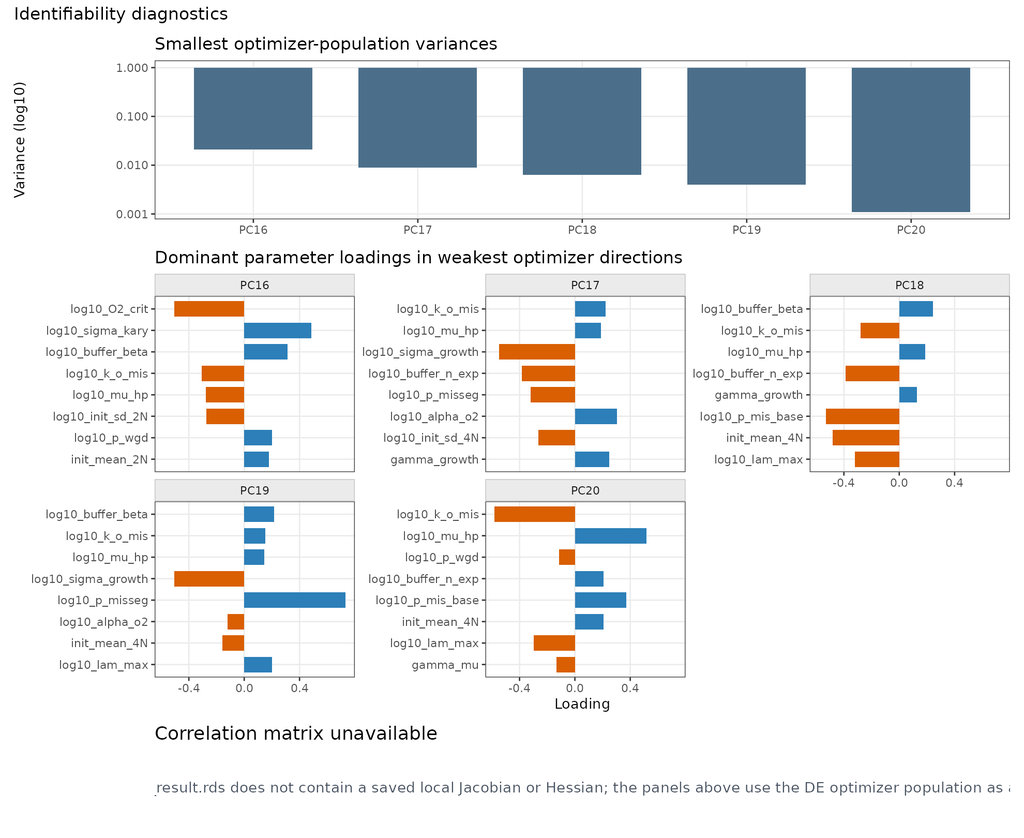

Local identifiability output for the current seed when available. If no Jacobian/Hessian was saved, the figure reports an optimizer-population proxy instead.

Embedded PDF source

## 3.2 Rate-Function Diagnostics

### Figure 2.1/2.4 Constant External Oxygen and Selected-Day Live Cells

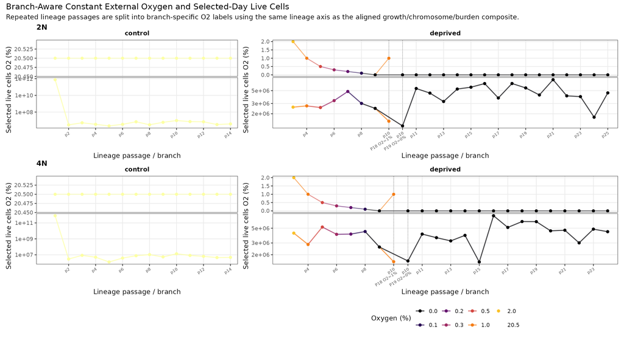

Branch-aware diagnostic for the in vitro runner. Each cohort is split into control/deprived lineage panels using the same branch-specific x-axis as the aligned growth/chromosome/burden composite; repeated lineage passages are not averaged across branches. The upper row shows external oxygen and the lower row shows selected-day predicted live cells.

Embedded PDF source

### Figure 2.2 Rate-Function Diagnostics

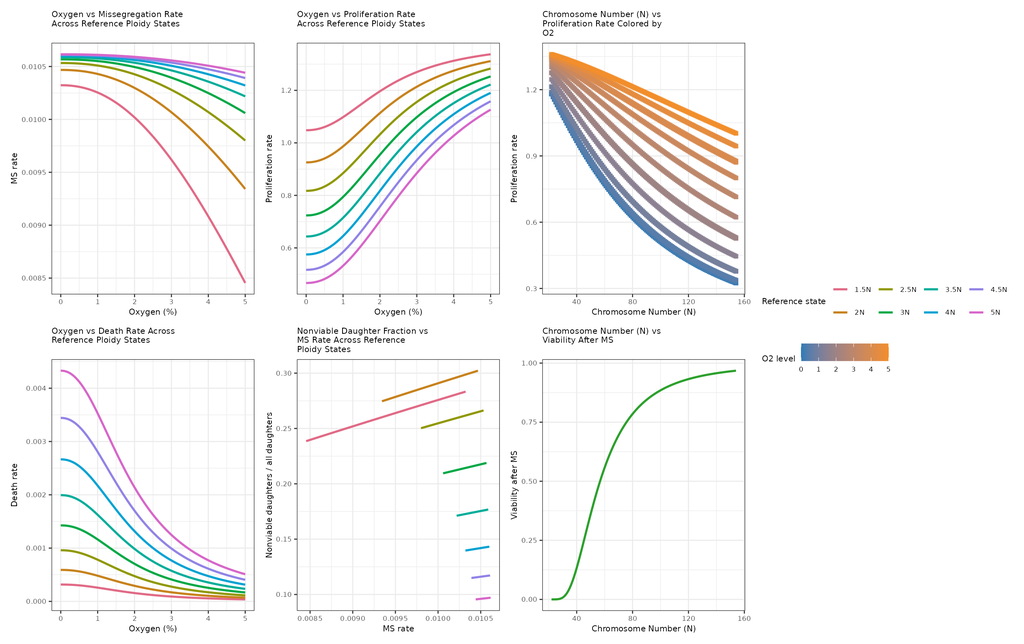

Best-fit oxygen, ploidy, death, proliferation, and missegregation rate functions for the current seed.

Embedded PDF source

### Figure 2.3 Daily Live-Cell Trajectories

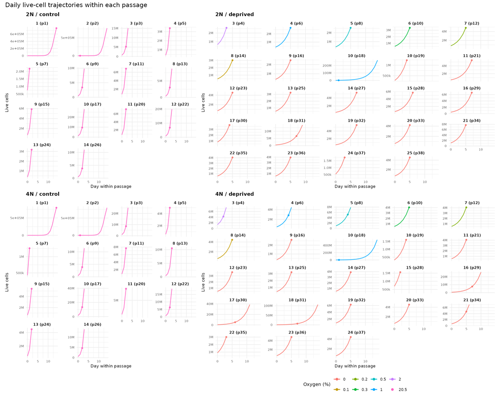

Predicted live-cell trajectories split into 2N/control, 2N/deprived, 4N/control, and 4N/deprived panels, with each lineage passage shown as an inset subplot; selected propagation days are marked.

Embedded PDF source

### Figure 2.5 Aligned Growth, Chromosome Count, and Burden Fit

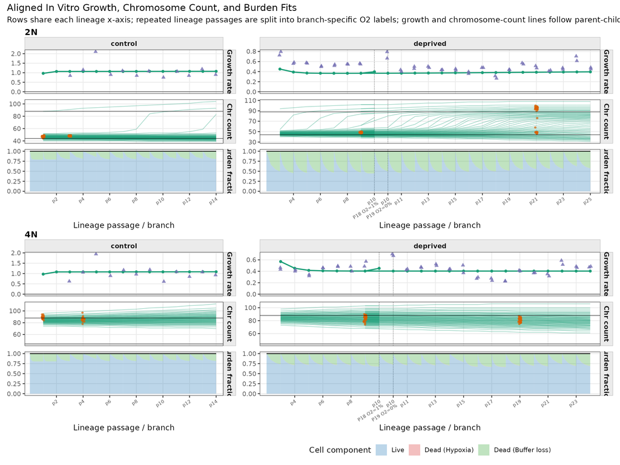

Composite in vitro fit view. The 2N and 4N cohort blocks are stacked vertically; each block contains growth rate, chromosome-count quantile, and burden-decomposition rows. Repeated lineage passages are split into branch-specific O2 x-axis labels rather than averaged together; growth-rate and chromosome-count lines follow parent-child lineage links, so parallel p10 branches both connect to their shared p9 parent. Observed growth-rate points are drawn at their own branch positions. In vitro burden components are live/dead fractions normalized by the displayed predicted cell components, so the burden row ranges from 0 to 1. Control and deprived panels use their own passage ranges, with rows aligned within each lineage panel.

Embedded PDF source

### Figure 2.6 Flow-Density Fit

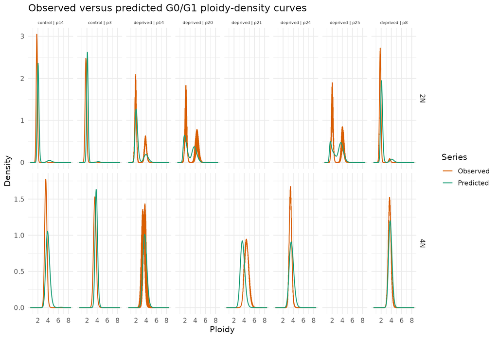

Observed G0/G1 ploidy-density curves are overlaid with the fitted flow-density prediction.

Embedded PDF source

### Figure 2.7 Predicted Ploidy Distribution

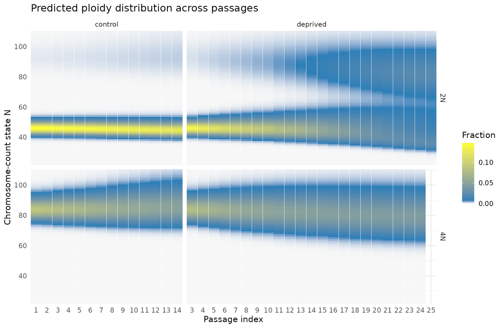

Full predicted chromosome-count distribution across in vitro passages.

Embedded PDF source

## 3.3 MS-Linked Viability and Death Relationships

### Figure 3.1 Nonviable Daughter Fraction vs MS Rate

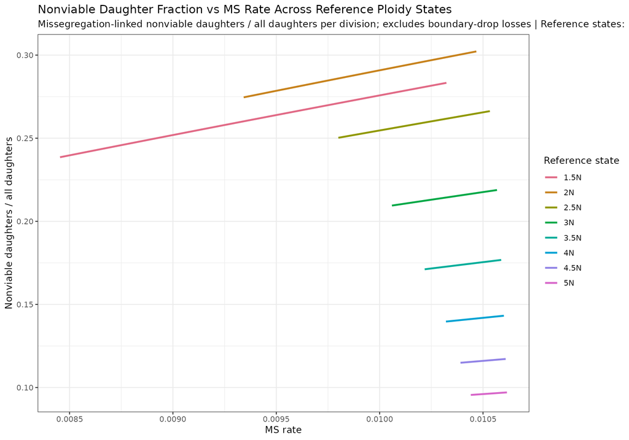

Per-division fraction of daughter cells that are nonviable because of missegregation-linked loss, shown against missegregation rate.

Embedded PDF source

### Figure 3.2 Death Rate vs Missegregation Rate

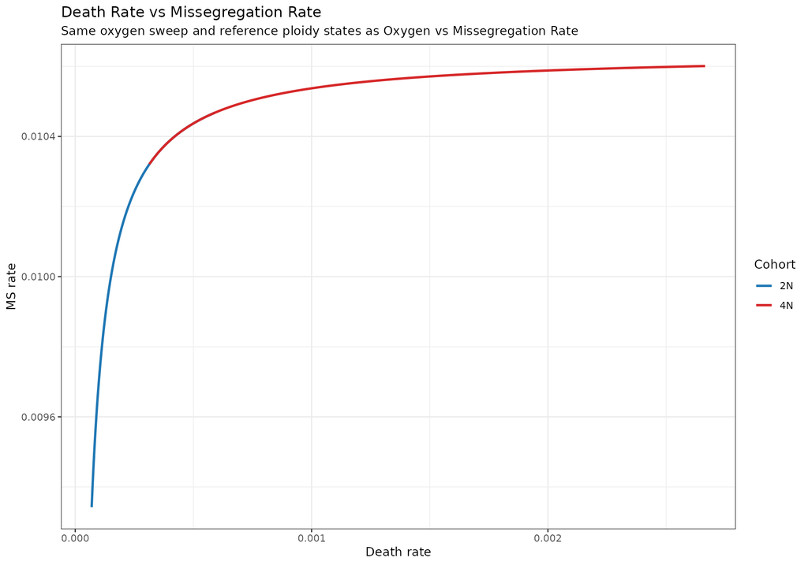

Missegregation-rate curve plotted against the fitted death rate at the 2N and 4N reference ploidy states.

Embedded PDF source

### Figure 3.3 Ploidy vs Viability After MS

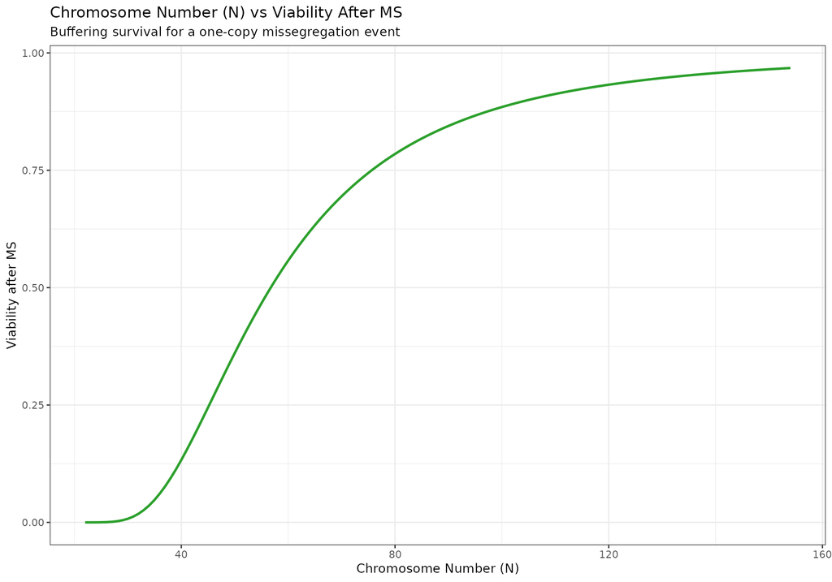

Viability modifier after a one-copy-loss missegregation event across the ploidy grid.

Embedded PDF source

## 3.4 Fixed-G0 O2 and Ploidy Diagnostics

### Figure 4.1 Ploidy vs Death Rate by O2: Fixed G=0

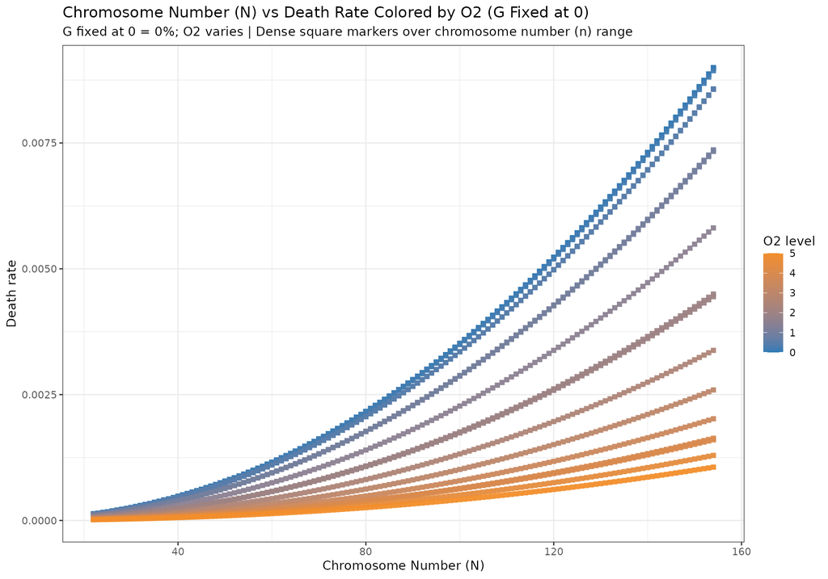

In vitro no-glucose diagnostic evaluated at fixed G=0 across the oxygen and ploidy grid.

Embedded PDF source

### Figure 4.2 Ploidy vs Proliferation Rate by O2: Fixed G=0

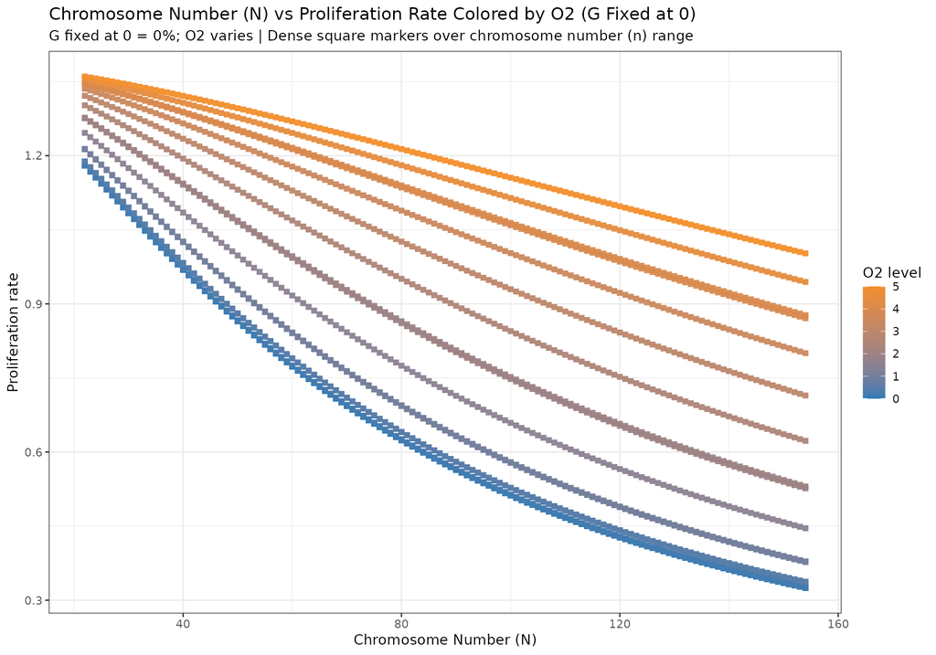

In vitro no-glucose diagnostic evaluated at fixed G=0 across the oxygen and ploidy grid.

Embedded PDF source

### Figure 4.3 Oxygen vs Missegregation Rate: Fixed G=0

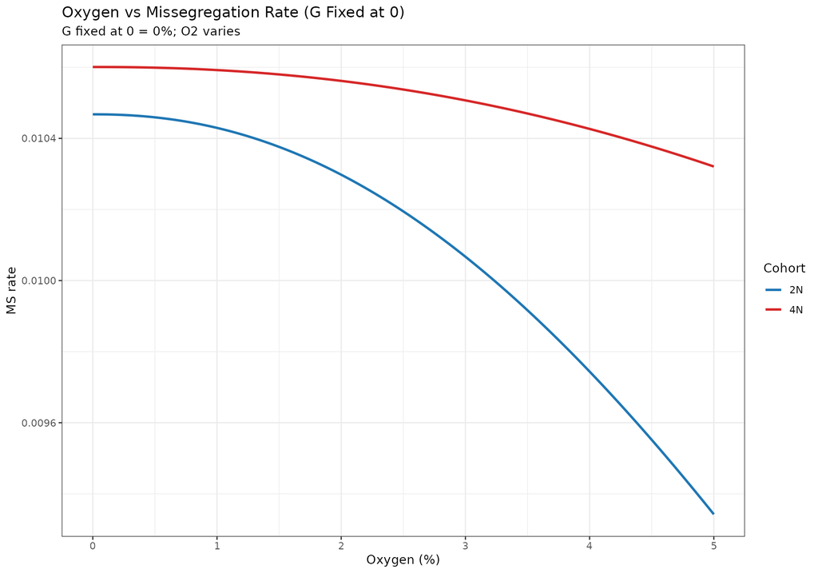

In vitro oxygen-response diagnostic for missegregation rate at fixed G=0.

Embedded PDF source

### Figure 4.4 Oxygen vs Missegregation Rate Across Ploidy States: Fixed G=0

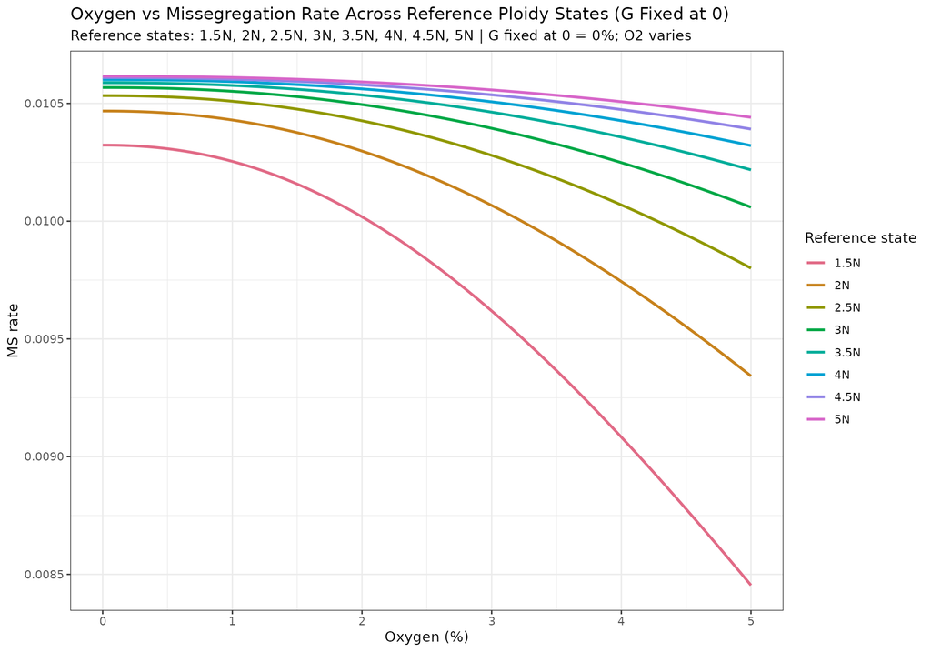

In vitro oxygen-response diagnostic for missegregation rate across reference ploidy states at fixed G=0.

Embedded PDF source

### Figure 4.5 Oxygen vs Proliferation Rate: Fixed G=0

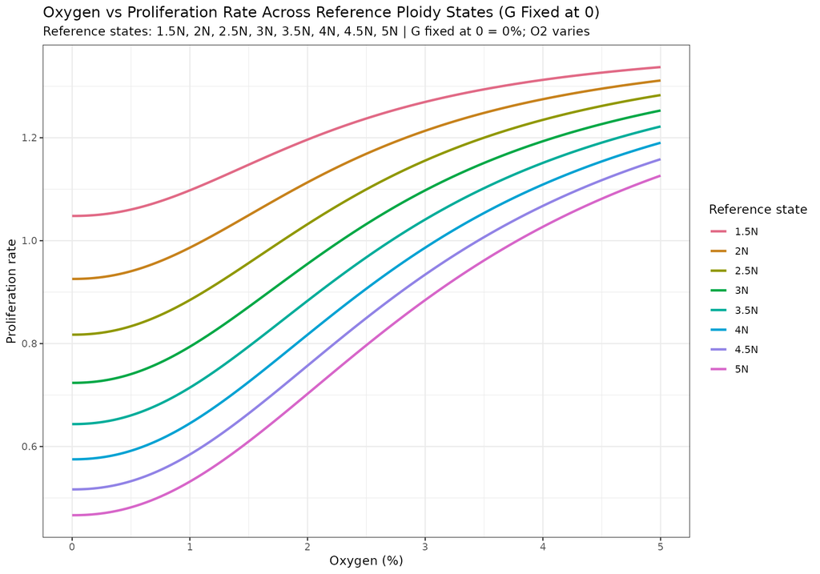

In vitro oxygen-response diagnostic for proliferation rate at fixed G=0.

Embedded PDF source

### Figure 4.6 Oxygen vs Death Rate: Fixed G=0

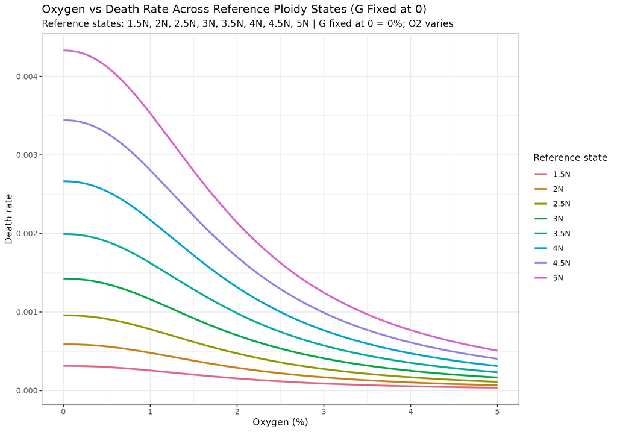

In vitro oxygen-response diagnostic for death rate at fixed G=0.

Embedded PDF source